# Data Visualization - Netflix

Rizki Aji Mahardika

5/2/2022

[figure not shown]

# 1 Intro

In this project, we will analyze data from Kaggle, namely Netflix data. Netflix is one of the most popular media and video streaming platforms. They have over 8000 movies or tv shows available on their platform, as of mid-2021, they have over 200M Subscribers globally. After we finish analyzing Netflix data, then we will visualize based on the results of the analysis that has been done.

## 1.1 Input Data

First, we need to read data

```r
netflix <- read.csv("data/netflix.csv")
```

Then, we want to see top 10 data owned by Netflix

```r
head(netflix,10)
```

|  | show_id | type | title | director | cast | country | date_added | release_year | rating | duration | listed_in | description |
| --- | --- | --- | --- | --- | --- | --- | --- | --- | --- | --- | --- | --- |
| 1 | s1 | Movie | Dick Johnson Is Dead | Kirsten Johnson |  | United States | September 25, 2021 | 2020 | PG-13 | 90 min | Documentaries | As her father nears the end of his life, filmmaker Kirsten Johnson stages his death in inventive and comical ways to help them both face the inevitable. |
| 2 | s2 | TV Show | Blood & Water |  | Ama Qamata, Khosi Ngema, Gail Mabalane, Thabang Molaba, Dillon Windvogel, Natasha Thahane, Arno Greeff, Xolile Tshabalala, Getmore Sithole, Cindy Mahlangu, Ryle De Morny, Greteli Fincham, Sello Maake … | South Africa | September 24, 2021 | 2021 | TV-MA | 2 Seasons | International TV Shows, TV Dramas, TV Mysteries | After crossing paths at a party, a Cape Town teen sets out to prove whether a private-school swimming star is her sister who was abducted at birth. |
| 3 | s3 | TV Show | Ganglands | Julien Leclercq | Sami Bouajila, Tracy Gotoas, Samuel Jouy, Nabiha Akkari, Sofia Lesaffre, Salim Kechiouche, Noureddine Farihi, Geert Van Rampelberg, Bakary Diombera |  | September 24, 2021 | 2021 | TV-MA | 1 Season | Crime TV Shows, International TV Shows, TV Action & Adventure | To protect his family from a powerful drug lord, skilled thief Mehdi and his expert team of robbers are pulled into a violent and deadly turf war. |
| 4 | s4 | TV Show | Jailbirds New Orleans |  |  |  | September 24, 2021 | 2021 | TV-MA | 1 Season | Docuseries, Reality TV | Feuds, flirtations and toilet talk go down among the incarcerated women at the Orleans Justice Center in New Orleans on this gritty reality series. |
| 5 | s5 | TV Show | Kota Factory |  | Mayur More, Jitendra Kumar, Ranjan Raj, Alam Khan, Ahsaas Channa, Revathi Pillai, Urvi Singh, Arun Kumar | India | September 24, 2021 | 2021 | TV-MA | 2 Seasons | International TV Shows, Romantic TV Shows, TV Comedies | In a city of coaching centers known to train Indiaâ\200\231s finest collegiate minds, an earnest but unexceptional student and his friends navigate campus life. |
| 6 | s6 | TV Show | Midnight Mass | Mike Flanagan | Kate Siegel, Zach Gilford, Hamish Linklater, Henry Thomas, Kristin Lehman, Samantha Sloyan, Igby Rigney, Rahul Kohli, Annarah Cymone, Annabeth Gish, Alex Essoe, Rahul Abburi, Matt Biedel, Michael Truc… |  | September 24, 2021 | 2021 | TV-MA | 1 Season | TV Dramas, TV Horror, TV Mysteries | The arrival of a charismatic young priest brings glorious miracles, ominous mysteries and renewed religious fervor to a dying town desperate to believe. |
| 7 | s7 | Movie | My Little Pony: A New Generation | Robert Cullen, JosÃ© Luis Ucha | Vanessa Hudgens, Kimiko Glenn, James Marsden, Sofia Carson, Liza Koshy, Ken Jeong, Elizabeth Perkins, Jane Krakowski, Michael McKean, Phil LaMarr |  | September 24, 2021 | 2021 | PG | 91 min | Children & Family Movies | Equestria's divided. But a bright-eyed hero believes Earth Ponies, Pegasi and Unicorns should be pals â\200” and, hoof to heart, sheâ\200\231s determined to prove it. |
| 8 | s8 | Movie | Sankofa | Haile Gerima | Kofi Ghanaba, Oyafunmike Ogunlano, Alexandra Duah, Nick Medley, Mutabaruka, Afemo Omilami, Reggie Carter, Mzuri | United States, Ghana, Burkina Faso, United Kingdom, Germany, Ethiopia | September 24, 2021 | 1993 | TV-MA | 125 min | Dramas, Independent Movies, International Movies | On a photo shoot in Ghana, an American model slips back in time, becomes enslaved on a plantation and bears witness to the agony of her ancestral past. |
| 9 | s9 | TV Show | The Great British Baking Show | Andy Devonshire | Mel Giedroyc, Sue Perkins, Mary Berry, Paul Hollywood | United Kingdom | September 24, 2021 | 2021 | TV-14 | 9 Seasons | British TV Shows, Reality TV | A talented batch of amateur bakers face off in a 10-week competition, whipping up their best dishes in the hopes of being named the U.K.'s best. |
| 10 | s10 | Movie | The Starling | Theodore Melfi | Melissa McCarthy, Chris O'Dowd, Kevin Kline, Timothy Olyphant, Daveed Diggs, Skyler Gisondo, Laura Harrier, Rosalind Chao, Kimberly Quinn, Loretta Devine, Ravi Kapoor | United States | September 24, 2021 | 2021 | PG-13 | 104 min | Comedies, Dramas | A woman adjusting to life after a loss contends with a feisty bird that's taken over her garden â\200” and a husband who's struggling to find a way forward. |

Next, we want to know dimension of data

```r
dim(netflix)
```

```
## [1] 8807   12
```

This data contains 8807 rows and 12 columns

# 2 Data Cleansing

The first step in conducting data analysis is to ensure that the data to be used is clean.

## 2.1 Load Libraries

First, we need to load required libraries

```r
library(tidyverse)
library(dplyr)
library(lubridate)
```

```r
library(ggplot2)
```

## 2.2 Explicit Coercion

Next, we need to check data types in every column

```r
str(netflix)
```

```
## 'data.frame':    8807 obs. of  12 variables:
##  $ show_id     : chr  "s1" "s2" "s3" "s4" ...
##  $ type        : chr  "Movie" "TV Show" "TV Show" "TV Show" ...
##  $ title       : chr  "Dick Johnson Is Dead" "Blood & Water" "Ganglands" "Jailbirds New Orleans" ...
##  $ director    : chr  "Kirsten Johnson" "" "Julien Leclercq" "" ...
##  $ cast        : chr  "" "Ama Qamata, Khosi Ngema, Gail Mabalane, Thabang Molaba, Dillon Windvogel, Natasha Thahane, Arno Greeff, Xolile "| __truncated__ "Sami Bouajila, Tracy Gotoas, Samuel Jouy, Nabiha Akkari, Sofia Lesaffre, Salim Kechiouche, Noureddine Farihi, G"| __truncated__ "" ...
##  $ country     : chr  "United States" "South Africa" "" "" ...
##  $ date_added  : chr  "September 25, 2021" "September 24, 2021" "September 24, 2021" "September 24, 2021" ...
##  $ release_year: int  2020 2021 2021 2021 2021 2021 2021 1993 2021 2021 ...
##  $ rating      : chr  "PG-13" "TV-MA" "TV-MA" "TV-MA" ...
##  $ duration    : chr  "90 min" "2 Seasons" "1 Season" "1 Season" ...
##  $ listed_in   : chr  "Documentaries" "International TV Shows, TV Dramas, TV Mysteries" "Crime TV Shows, International TV Shows, TV Action & Adventure" "Docuseries, Reality TV" ...
##  $ description : chr  "As her father nears the end of his life, filmmaker Kirsten Johnson stages his death in inventive and comical wa"| __truncated__ "After crossing paths at a party, a Cape Town teen sets out to prove whether a private-school swimming star is h"| __truncated__ "To protect his f…
```

Based on data type for each column above, there is an incorrect data type. Therefore, we have to change the data type

```r
netflix$type <- as.factor(netflix$type)
netflix$date_added <- mdy(netflix$date_added)
netflix$release_year <- parse_date_time(netflix$release_year,'y')
```

## 2.3 Check Missing Values

```r
colSums(is.na(netflix))
```

```
##      show_id         type        title     director         cast      country
##            0            0            0            0            0            0
##   date_added release_year       rating     duration    listed_in  description
##           10            0            0            0            0            0
```

We have missing values in column date_added, we will do action on NA and convert it to string “Missing Values”

```r
netflix$director[netflix$director==""] <- NA
netflix$cast[netflix$cast==""] <- NA
netflix$country[netflix$country==""] <- NA
netflix$rating[netflix$rating==""] <- NA
```

```r
netflix$director[which(is.na(netflix$director))] <- "Missing Values"
netflix$cast[which(is.na(netflix$cast))] <- "Missing Values"
netflix$country[which(is.na(netflix$country))] <- "Missing Values"
netflix$date_added[which(is.na(netflix$date_added))] <- "01-01-01" #because the date_added column has a date data type
netflix$rating[which(is.na(netflix$rating))] <- "Missing Values"
colSums(is.na(netflix))
```

```
##      show_id         type        title     director         cast      country
##            0            0            0            0            0            0
##   date_added release_year       rating     duration    listed_in  description
##            0            0            0            0            0            0
```

Great! We don’t have missing values.

## 2.4 Finishing Data Cleansing

First, we recheck data again.

```r
head(netflix,10)
```

|  | show_id | type | title | director | cast | country | date_added | release_year | rating | duration | listed_in | description |
| --- | --- | --- | --- | --- | --- | --- | --- | --- | --- | --- | --- | --- |
| 1 | s1 | Movie | Dick Johnson Is Dead | Kirsten Johnson | Missing Values | United States | 2021-09-25 | 2020-01-01 | PG-13 | 90 min | Documentaries | As her father nears the end of his life, filmmaker Kirsten Johnson stages his death in inventive and comical ways to help them both face the inevitable. |
| 2 | s2 | TV Show | Blood & Water | Missing Values | Ama Qamata, Khosi Ngema, Gail Mabalane, Thabang Molaba, Dillon Windvogel, Natasha Thahane, Arno Greeff, Xolile Tshabalala, Getmore Sithole, Cindy Mahlangu, Ryle De Morny, Greteli Fincham, Sello Maake … | South Africa | 2021-09-24 | 2021-01-01 | TV-MA | 2 Seasons | International TV Shows, TV Dramas, TV Mysteries | After crossing paths at a party, a Cape Town teen sets out to prove whether a private-school swimming star is her sister who was abducted at birth. |
| 3 | s3 | TV Show | Ganglands | Julien Leclercq | Sami Bouajila, Tracy Gotoas, Samuel Jouy, Nabiha Akkari, Sofia Lesaffre, Salim Kechiouche, Noureddine Farihi, Geert Van Rampelberg, Bakary Diombera | Missing Values | 2021-09-24 | 2021-01-01 | TV-MA | 1 Season | Crime TV Shows, International TV Shows, TV Action & Adventure | To protect his family from a powerful drug lord, skilled thief Mehdi and his expert team of robbers are pulled into a violent and deadly turf war. |
| 4 | s4 | TV Show | Jailbirds New Orleans | Missing Values | Missing Values | Missing Values | 2021-09-24 | 2021-01-01 | TV-MA | 1 Season | Docuseries, Reality TV | Feuds, flirtations and toilet talk go down among the incarcerated women at the Orleans Justice Center in New Orleans on this gritty reality series. |
| 5 | s5 | TV Show | Kota Factory | Missing Values | Mayur More, Jitendra Kumar, Ranjan Raj, Alam Khan, Ahsaas Channa, Revathi Pillai, Urvi Singh, Arun Kumar | India | 2021-09-24 | 2021-01-01 | TV-MA | 2 Seasons | International TV Shows, Romantic TV Shows, TV Comedies | In a city of coaching centers known to train Indiaâ\200\231s finest collegiate minds, an earnest but unexceptional student and his friends navigate campus life. |
| 6 | s6 | TV Show | Midnight Mass | Mike Flanagan | Kate Siegel, Zach Gilford, Hamish Linklater, Henry Thomas, Kristin Lehman, Samantha Sloyan, Igby Rigney, Rahul Kohli, Annarah Cymone, Annabeth Gish, Alex Essoe, Rahul Abburi, Matt Biedel, Michael Truc… | Missing Values | 2021-09-24 | 2021-01-01 | TV-MA | 1 Season | TV Dramas, TV Horror, TV Mysteries | The arrival of a charismatic young priest brings glorious miracles, ominous mysteries and renewed religious fervor to a dying town desperate to believe. |
| 7 | s7 | Movie | My Little Pony: A New Generation | Robert Cullen, JosÃ© Luis Ucha | Vanessa Hudgens, Kimiko Glenn, James Marsden, Sofia Carson, Liza Koshy, Ken Jeong, Elizabeth Perkins, Jane Krakowski, Michael McKean, Phil LaMarr | Missing Values | 2021-09-24 | 2021-01-01 | PG | 91 min | Children & Family Movies | Equestria's divided. But a bright-eyed hero believes Earth Ponies, Pegasi and Unicorns should be pals â\200” and, hoof to heart, sheâ\200\231s determined to prove it. |
| 8 | s8 | Movie | Sankofa | Haile Gerima | Kofi Ghanaba, Oyafunmike Ogunlano, Alexandra Duah, Nick Medley, Mutabaruka, Afemo Omilami, Reggie Carter, Mzuri | United States, Ghana, Burkina Faso, United Kingdom, Germany, Ethiopia | 2021-09-24 | 1993-01-01 | TV-MA | 125 min | Dramas, Independent Movies, International Movies | On a photo shoot in Ghana, an American model slips back in time, becomes enslaved on a plantation and bears witness to the agony of her ancestral past. |
| 9 | s9 | TV Show | The Great British Baking Show | Andy Devonshire | Mel Giedroyc, Sue Perkins, Mary Berry, Paul Hollywood | United Kingdom | 2021-09-24 | 2021-01-01 | TV-14 | 9 Seasons | British TV Shows, Reality TV | A talented batch of amateur bakers face off in a 10-week competition, whipping up their best dishes in the hopes of being named the U.K.'s best. |
| 10 | s10 | Movie | The Starling | Theodore Melfi | Melissa McCarthy, Chris O'Dowd, Kevin Kline, Timothy Olyphant, Daveed Diggs, Skyler Gisondo, Laura Harrier, Rosalind Chao, Kimberly Quinn, Loretta Devine, Ravi Kapoor | United States | 2021-09-24 | 2021-01-01 | PG-13 | 104 min | Comedies, Dramas | A woman adjusting to life after a loss contends with a feisty bird that's taken over her garden â\200” and a husband who's struggling to find a way forward. |

```r
netflix <- netflix %>% select(,c(-"show_id",-"director",-"cast",-"country",-"description"))
head(netflix,10)
```

|  | type | title | date_added | release_year | rating | duration | listed_in |
| --- | --- | --- | --- | --- | --- | --- | --- |
| 1 | Movie | Dick Johnson Is Dead | 2021-09-25 | 2020-01-01 | PG-13 | 90 min | Documentaries |
| 2 | TV Show | Blood & Water | 2021-09-24 | 2021-01-01 | TV-MA | 2 Seasons | International TV Shows, TV Dramas, TV Mysteries |
| 3 | TV Show | Ganglands | 2021-09-24 | 2021-01-01 | TV-MA | 1 Season | Crime TV Shows, International TV Shows, TV Action & Adventure |
| 4 | TV Show | Jailbirds New Orleans | 2021-09-24 | 2021-01-01 | TV-MA | 1 Season | Docuseries, Reality TV |
| 5 | TV Show | Kota Factory | 2021-09-24 | 2021-01-01 | TV-MA | 2 Seasons | International TV Shows, Romantic TV Shows, TV Comedies |
| 6 | TV Show | Midnight Mass | 2021-09-24 | 2021-01-01 | TV-MA | 1 Season | TV Dramas, TV Horror, TV Mysteries |
| 7 | Movie | My Little Pony: A New Generation | 2021-09-24 | 2021-01-01 | PG | 91 min | Children & Family Movies |
| 8 | Movie | Sankofa | 2021-09-24 | 1993-01-01 | TV-MA | 125 min | Dramas, Independent Movies, International Movies |
| 9 | TV Show | The Great British Baking Show | 2021-09-24 | 2021-01-01 | TV-14 | 9 Seasons | British TV Shows, Reality TV |
| 10 | Movie | The Starling | 2021-09-24 | 2021-01-01 | PG-13 | 104 min | Comedies, Dramas |

we want to take the first category from listed_in columns

```r
netflix <- netflix %>% separate(listed_in, c("category", "category2", "category3"), sep = ",")
netflix <- netflix %>% select(c(-"category2", -"category3"))
head(netflix,10)
```

|  | type | title | date_added | release_year | rating | duration | category |
| --- | --- | --- | --- | --- | --- | --- | --- |
| 1 | Movie | Dick Johnson Is Dead | 2021-09-25 | 2020-01-01 | PG-13 | 90 min | Documentaries |
| 2 | TV Show | Blood & Water | 2021-09-24 | 2021-01-01 | TV-MA | 2 Seasons | International TV Shows |
| 3 | TV Show | Ganglands | 2021-09-24 | 2021-01-01 | TV-MA | 1 Season | Crime TV Shows |
| 4 | TV Show | Jailbirds New Orleans | 2021-09-24 | 2021-01-01 | TV-MA | 1 Season | Docuseries |
| 5 | TV Show | Kota Factory | 2021-09-24 | 2021-01-01 | TV-MA | 2 Seasons | International TV Shows |
| 6 | TV Show | Midnight Mass | 2021-09-24 | 2021-01-01 | TV-MA | 1 Season | TV Dramas |
| 7 | Movie | My Little Pony: A New Generation | 2021-09-24 | 2021-01-01 | PG | 91 min | Children & Family Movies |
| 8 | Movie | Sankofa | 2021-09-24 | 1993-01-01 | TV-MA | 125 min | Dramas |
| 9 | TV Show | The Great British Baking Show | 2021-09-24 | 2021-01-01 | TV-14 | 9 Seasons | British TV Shows |
| 10 | Movie | The Starling | 2021-09-24 | 2021-01-01 | PG-13 | 104 min | Comedies |

Finally, we want to create a new column, namely year added and month added from date_added column

```r
netflix$year_added <- year(netflix$date_added)
netflix$month_added <- month(netflix$date_added,label=T)
head(netflix,10)
```

|  | type | title | date_added | release_year | rating | duration | category | year_added | month_added |
| --- | --- | --- | --- | --- | --- | --- | --- | --- | --- |
| 1 | Movie | Dick Johnson Is Dead | 2021-09-25 | 2020-01-01 | PG-13 | 90 min | Documentaries | 2021 | Sep |
| 2 | TV Show | Blood & Water | 2021-09-24 | 2021-01-01 | TV-MA | 2 Seasons | International TV Shows | 2021 | Sep |
| 3 | TV Show | Ganglands | 2021-09-24 | 2021-01-01 | TV-MA | 1 Season | Crime TV Shows | 2021 | Sep |
| 4 | TV Show | Jailbirds New Orleans | 2021-09-24 | 2021-01-01 | TV-MA | 1 Season | Docuseries | 2021 | Sep |
| 5 | TV Show | Kota Factory | 2021-09-24 | 2021-01-01 | TV-MA | 2 Seasons | International TV Shows | 2021 | Sep |
| 6 | TV Show | Midnight Mass | 2021-09-24 | 2021-01-01 | TV-MA | 1 Season | TV Dramas | 2021 | Sep |
| 7 | Movie | My Little Pony: A New Generation | 2021-09-24 | 2021-01-01 | PG | 91 min | Children & Family Movies | 2021 | Sep |
| 8 | Movie | Sankofa | 2021-09-24 | 1993-01-01 | TV-MA | 125 min | Dramas | 2021 | Sep |
| 9 | TV Show | The Great British Baking Show | 2021-09-24 | 2021-01-01 | TV-14 | 9 Seasons | British TV Shows | 2021 | Sep |
| 10 | Movie | The Starling | 2021-09-24 | 2021-01-01 | PG-13 | 104 min | Comedies | 2021 | Sep |

Data cleaning has been completed and is ready to be used for analysis and visualization

# 3 Data Explanation

```r
summary(netflix)
```

```
##       type         title             date_added
##  Movie  :6131   Length:8807        Min.   :0001-01-01
##  TV Show:2676   Class :character   1st Qu.:2018-04-03
##                 Mode  :character   Median :2019-07-01
##                                    Mean   :2017-01-30
##                                    3rd Qu.:2020-08-18
##                                    Max.   :2021-09-25
##
##   release_year                    rating            duration
##  Min.   :1925-01-01 00:00:00   Length:8807        Length:8807
##  1st Qu.:2013-01-01 00:00:00   Class :character   Class :character
##  Median :2017-01-01 00:00:00   Mode  :character   Mode  :character
##  Mean   :2014-03-07 16:27:24
##  3rd Qu.:2019-01-01 00:00:00
##  Max.   :2021-01-01 00:00:00
##
##    category           year_added    month_added
##  Length:8807        Min.   :   1   Jul    : 827
##  Class :character   1st Qu.:2018   Dec    : 813
##  Mode  :character   Median :2019   Sep    : 770
##                     Mean   :2017   Apr    : 764
##                     3rd Qu.:2020   Oct    : 760
##                     Max.   :2021   Aug    : 755
##                                    (Other):4118
```

1. In column type in Netflix data, Movie has 6131 titles and TV show have 2676 titles
2. In this data used, the last data entered in Netflix is September 25th, 2021
3. The year of release of Movie/TV Show on Netflix is in the range 1925 - 2021
4. The maximum year for Movie/TV Show added by Netflix is 2021
5. Netflix most often added Movie/TV Show in July, December, and September

# 4 Study Case

1.Show comparison between type of Movie or type of TV Show by year of release

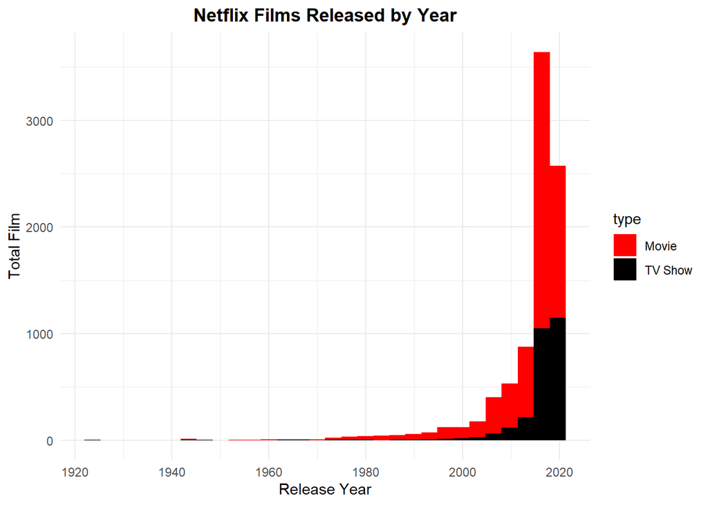

```r
ggplot(netflix, mapping = aes(x=release_year, fill = type)) +
  geom_histogram()+
  labs(title="Netflix Films Released by Year", x="Release Year", y="Total Film")+
  scale_fill_manual(values = c("Movie" = "Red","TV Show" = "Black"))+
  theme_minimal()+
  theme(plot.title = element_text(face="bold",hjust = 0.5))
```

2. What categories are included in the top 10 categories on Netflix

```r
top_categories <- netflix %>% group_by(category) %>% count() %>% arrange(desc(n))
top10_categories <- top_categories %>% filter(n>270)

top10_categories
```

| category | n |
| --- | --- |
| Dramas | 1600 |
| Comedies | 1210 |
| Action & Adventure | 859 |
| Documentaries | 829 |
| International TV Shows | 774 |
| Children & Family Movies | 605 |
| Crime TV Shows | 399 |
| Kids' TV | 388 |
| Stand-Up Comedy | 334 |
| Horror Movies | 275 |

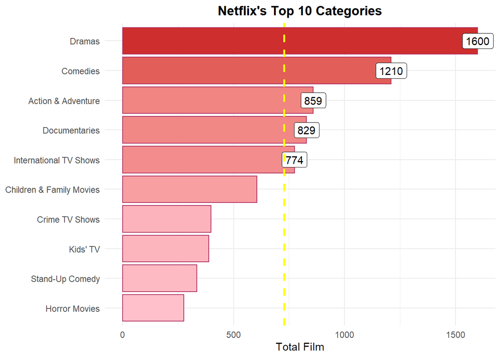

```r
ggplot(top10_categories,mapping=aes(x=n, reorder(category,n)))+
  geom_col(aes(fill=n),color = "maroon",show.legend = F)+
  scale_fill_gradient(low="pink",high="#cf2e2e")+
  labs(title = "Netflix's Top 10 Categories", x = "Total Film", y = NULL)+
  theme_minimal()+
  theme(plot.title=element_text(face="bold", hjust = 0.5))+
  geom_label(data=top10_categories[1:5,], mapping=aes(label=n))+
  geom_vline(xintercept = mean(top10_categories$n), col="yellow",linetype=2,lwd=1)
```

**Answer : The plot above is a visualization of the top 10 categories on Netflix. There is a yellow line indicating the average of the categories. There are 5 categories that exceed the average, namely the category Dramas, Comedies, Action & Adventure, Documentaries, International TV Shows**

3. What ratings are included in the top 10 categories on Netflix

```r
top_ratings <- netflix %>% group_by(rating) %>% count() %>% arrange(desc(n))
top10_ratings <- top_ratings %>% filter(n>50)

top10_ratings
```

| rating | n |
| --- | --- |
| TV-MA | 3207 |
| TV-14 | 2160 |
| TV-PG | 863 |
| R | 799 |
| PG-13 | 490 |
| TV-Y7 | 334 |
| TV-Y | 307 |
| PG | 287 |
| TV-G | 220 |
| NR | 80 |

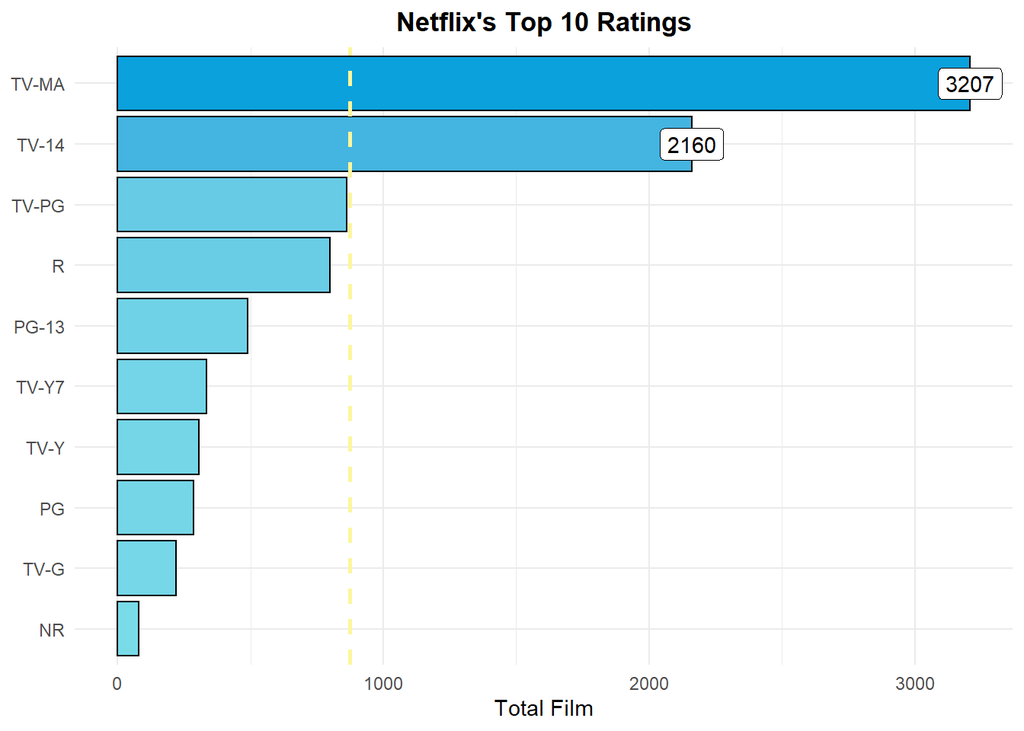

```r
ggplot(data = top10_ratings, mapping=aes(x=n,y=reorder(rating,n)))+
  geom_col(aes(fill=n), color="black", show.legend = F)+
  scale_fill_gradient(low="#79DAE8",high="#0AA1DD")+
  labs(title="Netflix's Top 10 Ratings", x = "Total Film", y= NULL)+
  theme_minimal()+
  theme(plot.title = element_text(face="bold",hjust=0.5))+
  geom_label(data = top10_ratings[1:2,], mapping=aes(label=n))+
  geom_vline(xintercept = mean(top10_ratings$n), col = "#FCF69C",linetype=2,lwd=1)
```

**Answer : The plot above is a visualization of the top 10 ratings on Netflix. There is a yellow line indicating the average of ratings. There are two ratings that exceed the average, namely the rating TV-MA and TV-14**

4. What month does Netflix add the most films?

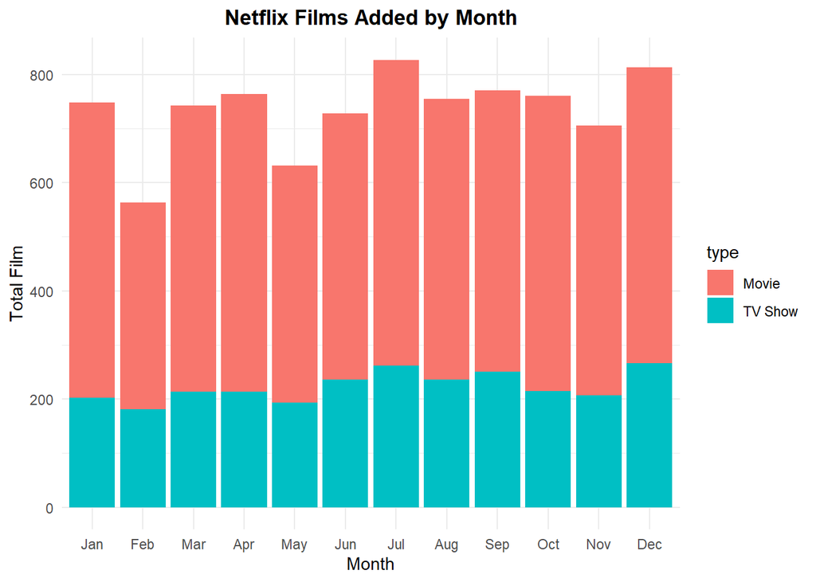

```r
netflix %>% group_by(month_added,type)%>%
  count() %>%
  ggplot(aes(x=month_added,y=n,fill=type))+
  geom_col(aes(fill=type))+
  labs(title="Netflix Films Added by Month", x="Month", y="Total Film")+
  theme_minimal()+
  theme(plot.title=element_text(face="bold",hjust=0.5))
```

**Answer : From the plot above, trend type Movies are higher than trend type TV Shows. Then, the month that Netflix adds films most often are July, September, and December**

5. Show the trend of the duration of type movies from 2000 to 2020

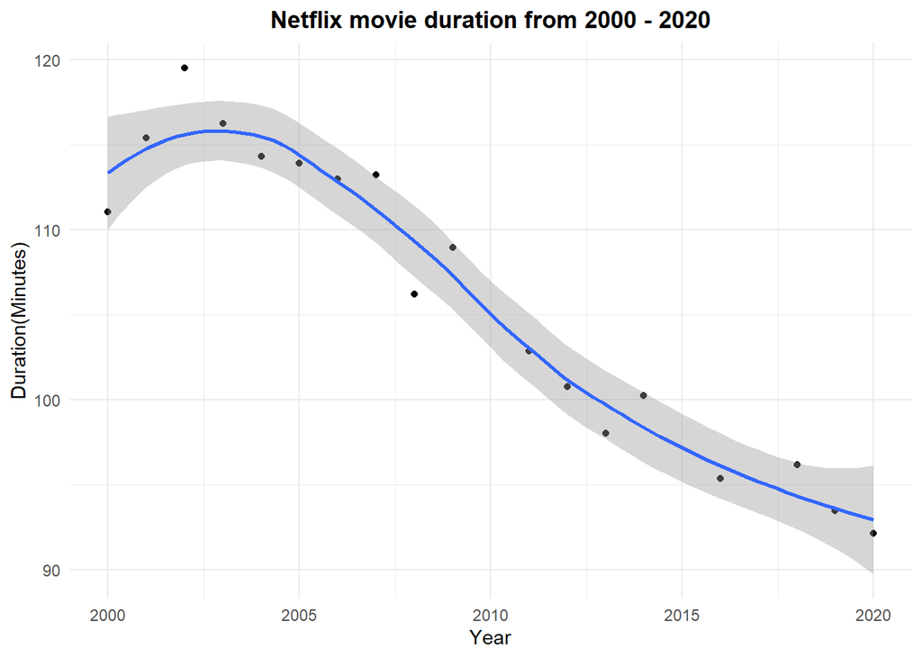

```r
netflix %>%
  filter(type=='Movie' & release_year>="2000-01-01" & release_year<="2020-01-02") %>%
  mutate(movie_duration=substr(duration,1,nchar(as.character(duration))-4)) %>%
  mutate(movie_duration = as.integer(movie_duration)) %>%
  group_by(release_year) %>%
  summarise(avg_duration = mean(movie_duration)) %>%
  ggplot(aes(x=release_year, y= avg_duration))+
  geom_point() + geom_smooth()+
  labs(title = "Netflix movie duration from 2000 - 2020", x = "Year", y = "Duration(Minutes)")+
  theme_minimal()+
  theme(plot.title=element_text(face="bold",hjust=0.5))
```

**Answer : The plot above shows that the duration of movies from 2000 to 2020 has a downward trend.**

# 5 Final Conclusion

Then two ratings exceed the average rating, namely the rating TV-MA and TV-14. Trend type Movies are higher than the trend type TV Shows. The month that Netflix adds films most often are July, September, and December. Finally, the duration of movies from 2000 to 2020 has a downward trend.